# Project 3

Alexander Quinter

## Introduction

Urban Ministries is a non-profit organization that seeks to provide food, job opportunities, and other services to the homeless community of Durham and the surrounding area. I believe that how long clients stay with UMD is an overall measure of UMD’s ability to service its clientele, and factors that are significantly associated with this measure may indicate groups that may need more assistance than others. Besides demographic factors, I believe that what disabilities the clients have, if any, may also be associated with the length of their stay. Specifically, I decided to look at five of the disabilities that had been defined by Housing and Urban Development (HUD), as these are ones that are broadly used and recognized and, unlike the “HIV/AIDS” and “Physical” categories, were neither too specific nor too general in what they could indicate. I was also curious as to whether any demographic factors seemed to be related to whether or not a client had a disability and what factors, if any, were associated with clients who had a disability when they started their stay at UMD, but no longer had one at the time of their exit. Using a logistic regression, I plan to identify potential factors associated with this phenomenon, so that UMD may identify what areas are most likely to assist clients with treatable disabilities. Using these analyses, I hope for UMD to gain a better understanding of how disabilities affect clients and subsequently improve their services to better aid them.

```r
#load in dataset
analysis.data = fread(file="C:/Users/alex/analysis_data.csv")
```

## Analysis

First, I decided to look at client counts by race and by gender in order to get an understanding of the general demographic makeup of UMD’s client base.

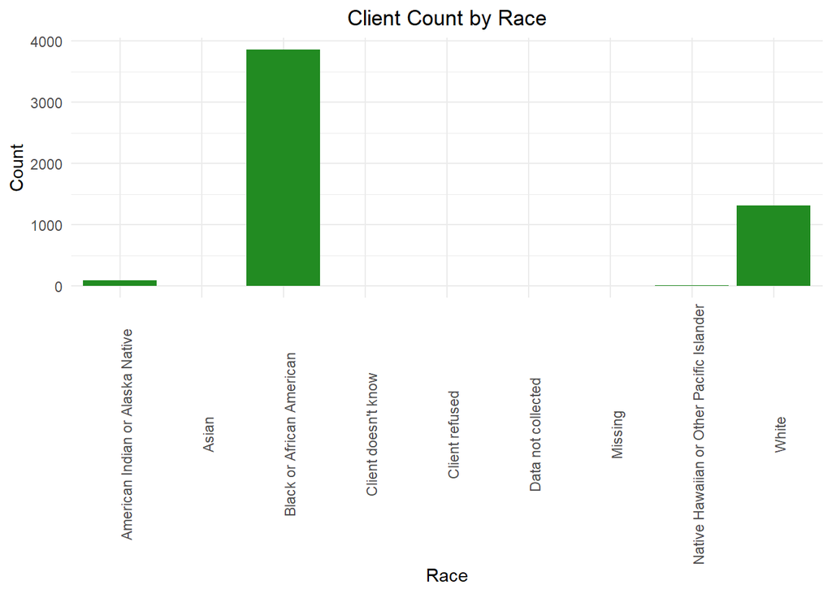

```r
#Create barplots of counts of UMD clients by race and gender respectively
ggplot(analysis.data, aes(x=`Client Primary Race`)) + geom_bar(stat="count", fill = "forestgreen") + theme_minimal() + labs(x = "Race", y = "Count") + ggtitle("Client Count by Race") + theme(axis.text.x =  element_text(angle = 90), plot.title = element_text(hjust=0.5))
```

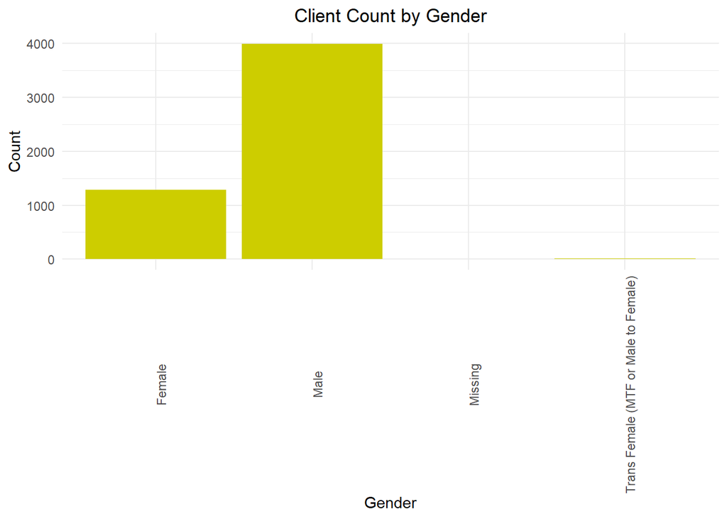

```r
ggplot(analysis.data, aes(x=`Client Gender`)) + geom_bar(stat="count", fill = "yellow3") + theme_minimal() + labs(x = "Gender", y = "Count") + ggtitle("Client Count by Gender") + theme(axis.text.x =  element_text(angle = 90), plot.title = element_text(hjust=0.5))
```

From the graphs above, it appears that most of UMD’s clients are African American/Black and male, while less than half are white, American Indian, or female. Thus, as the demographics aren’t balanced, statistical analyses that do not account for said inbalance may be inaccurate, if it turns out that the results of said analyses depend upon client gender or race.

To get a better idea as to whether or not this imbalance was the same across the different kinds of disabilities, or if it was actually further unbalanced and differed between each disability, I looked at graphs of the counts of how many people had each disability and stratified said graphs based on race and gender, respectively. This also allowed me to get an overall view of the frequency with which each disability occurs, and whether there were any disabilities that appeared to be more common than others.

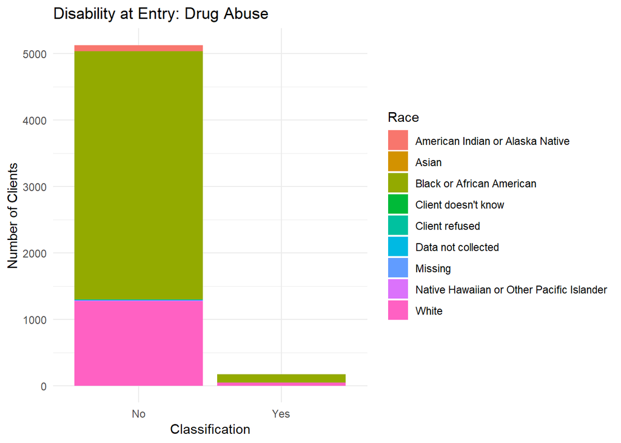

```r
#create bar plots for disabilities stratified by Gender and Race
ggplot(analysis.data, aes(x=`Drug Abuse_Entry`)) + geom_bar(aes(fill=`Client Primary Race`),stat = "count") + labs(x="Classification", y="Number of Clients", fill = "Race") + ggtitle("Disability at Entry: Drug Abuse") + theme_minimal()
```

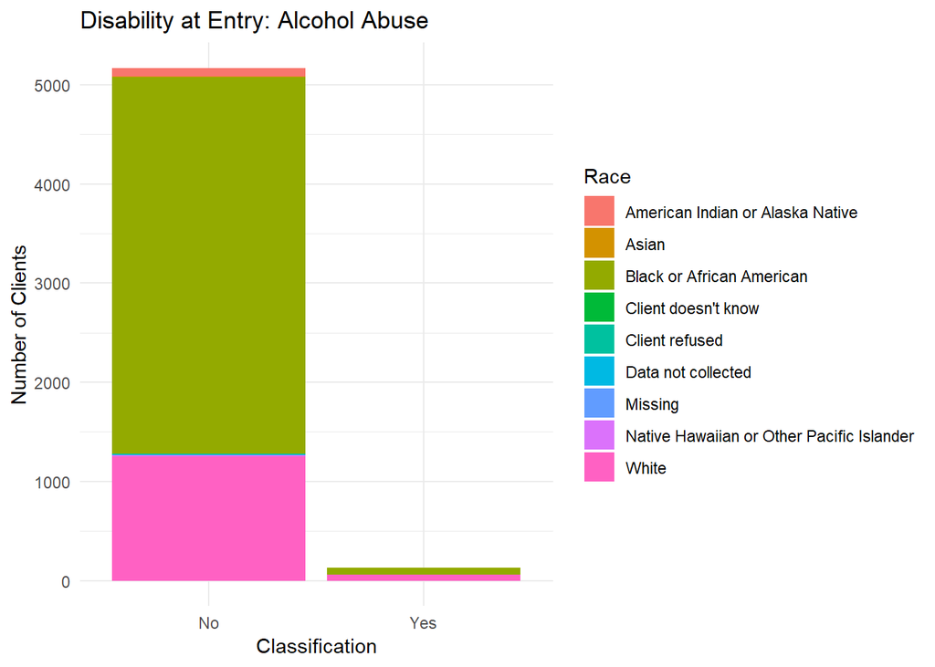

```r
ggplot(analysis.data, aes(x=`Alcohol Abuse_Entry`)) + geom_bar(aes(fill=`Client Primary Race`),stat = "count") + labs(x="Classification", y="Number of Clients", fill = "Race") + ggtitle("Disability at Entry: Alcohol Abuse") + theme_minimal()
```

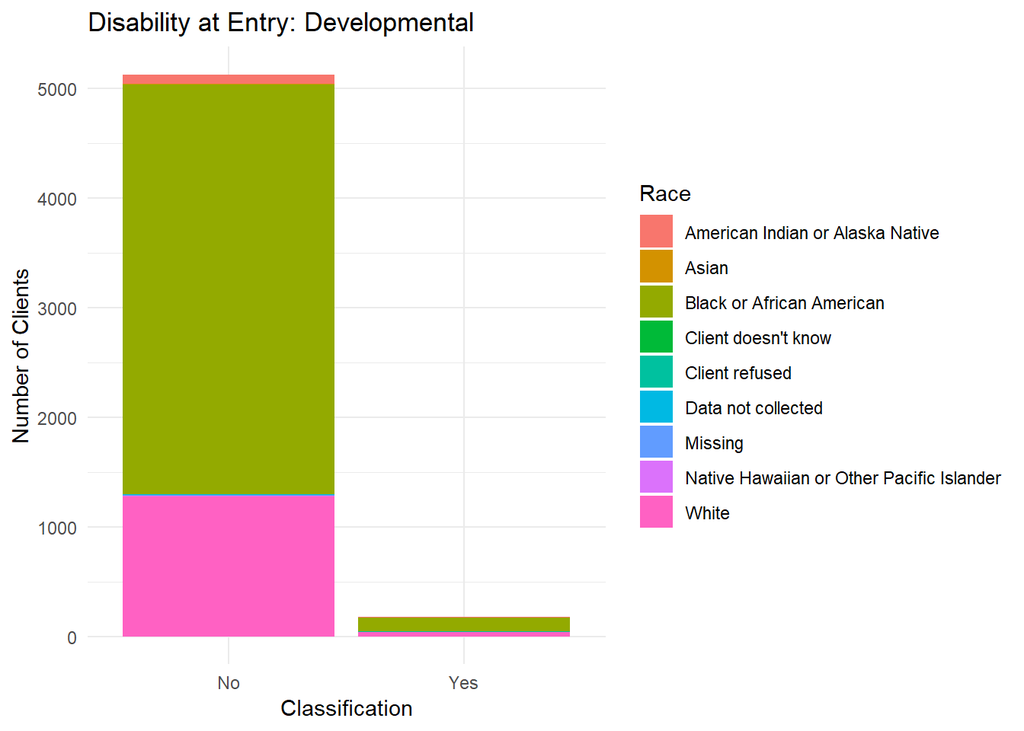

```r
ggplot(analysis.data, aes(x=`Developmental_Entry`)) + geom_bar(aes(fill=`Client Primary Race`),stat = "count") + labs(x="Classification", y="Number of Clients", fill = "Race") + ggtitle("Disability at Entry: Developmental") + theme_minimal()
```

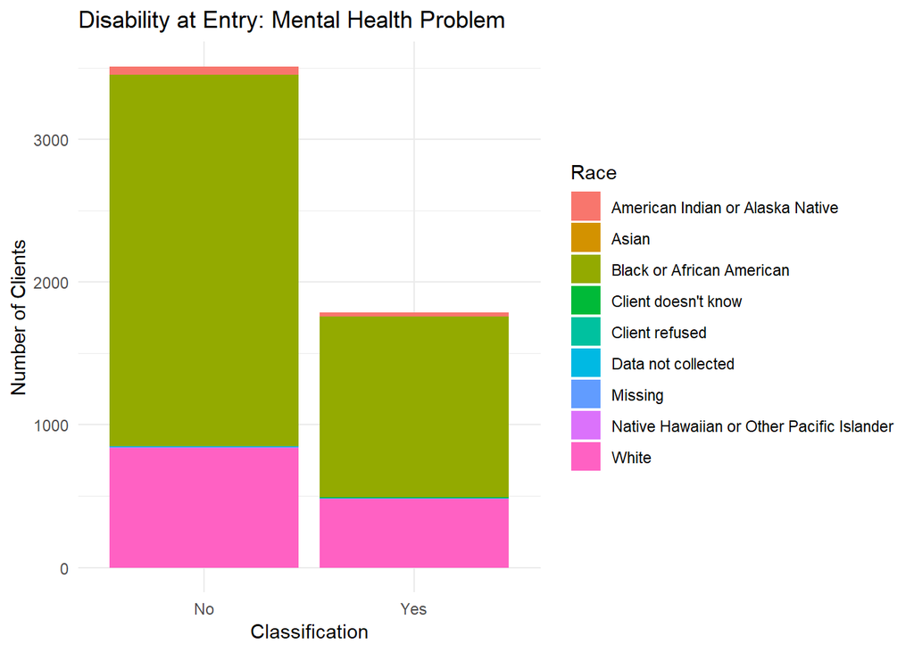

```r
ggplot(analysis.data, aes(x=`Mental Health Problem_Entry`)) + geom_bar(aes(fill=`Client Primary Race`),stat = "count") + labs(x="Classification", y="Number of Clients", fill = "Race") + ggtitle("Disability at Entry: Mental Health Problem") + theme_minimal()
```

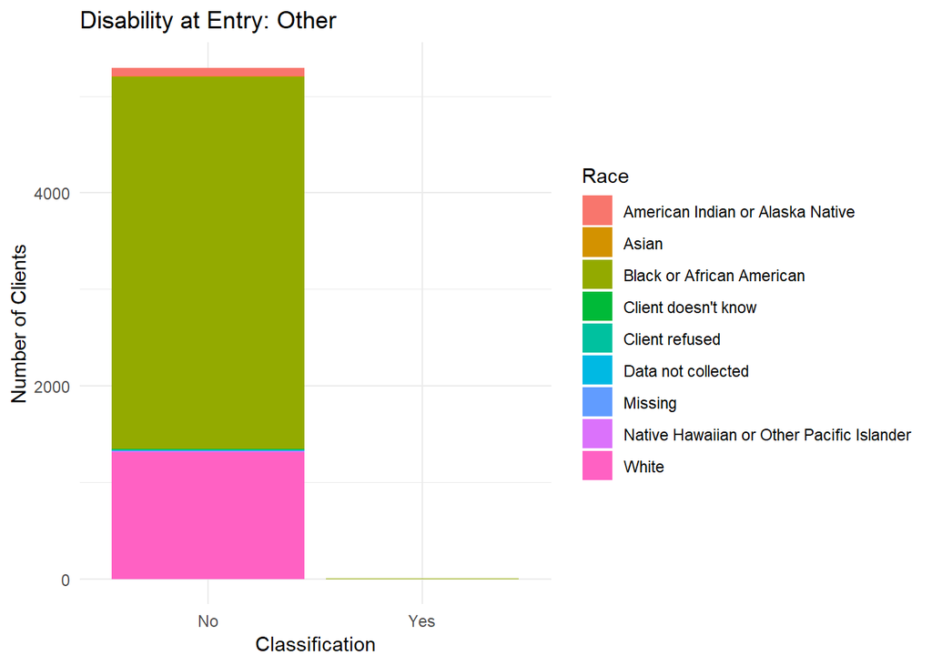

```r
ggplot(analysis.data, aes(x=`Other_Entry`)) + geom_bar(aes(fill=`Client Primary Race`),stat = "count") + labs(x="Classification", y="Number of Clients", fill = "Race") + ggtitle("Disability at Entry: Other") + theme_minimal()
```

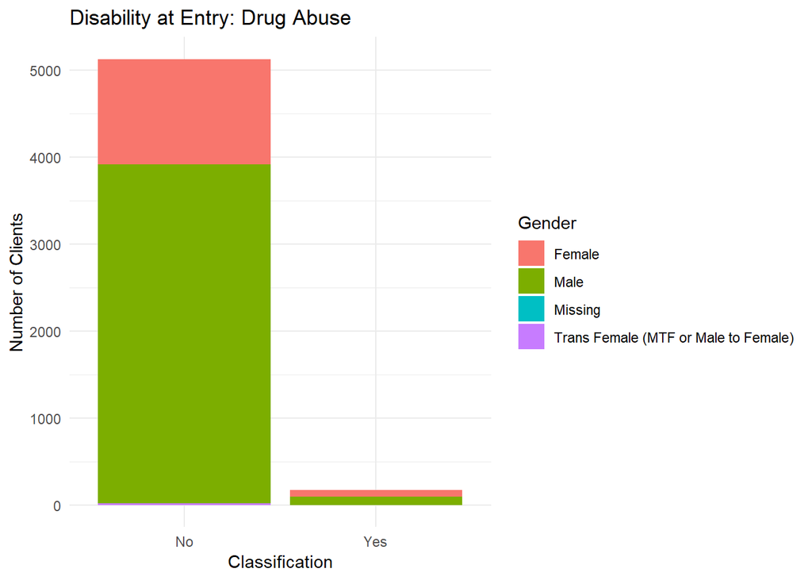

```r
ggplot(analysis.data, aes(x=`Drug Abuse_Entry`)) + geom_bar(aes(fill=`Client Gender`),stat = "count") + labs(x="Classification", y="Number of Clients", fill = "Gender") + ggtitle("Disability at Entry: Drug Abuse") + theme_minimal()
```

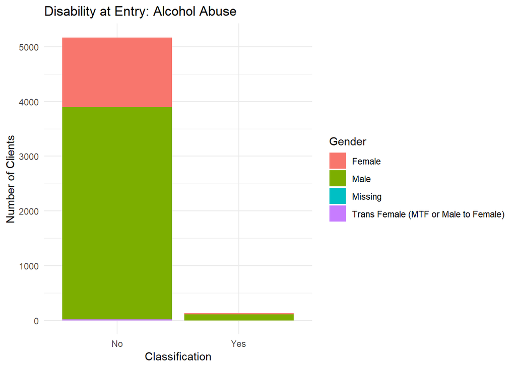

```r
ggplot(analysis.data, aes(x=`Alcohol Abuse_Entry`)) + geom_bar(aes(fill=`Client Gender`),stat = "count") + labs(x="Classification", y="Number of Clients", fill="Gender") + ggtitle("Disability at Entry: Alcohol Abuse") + theme_minimal()
```

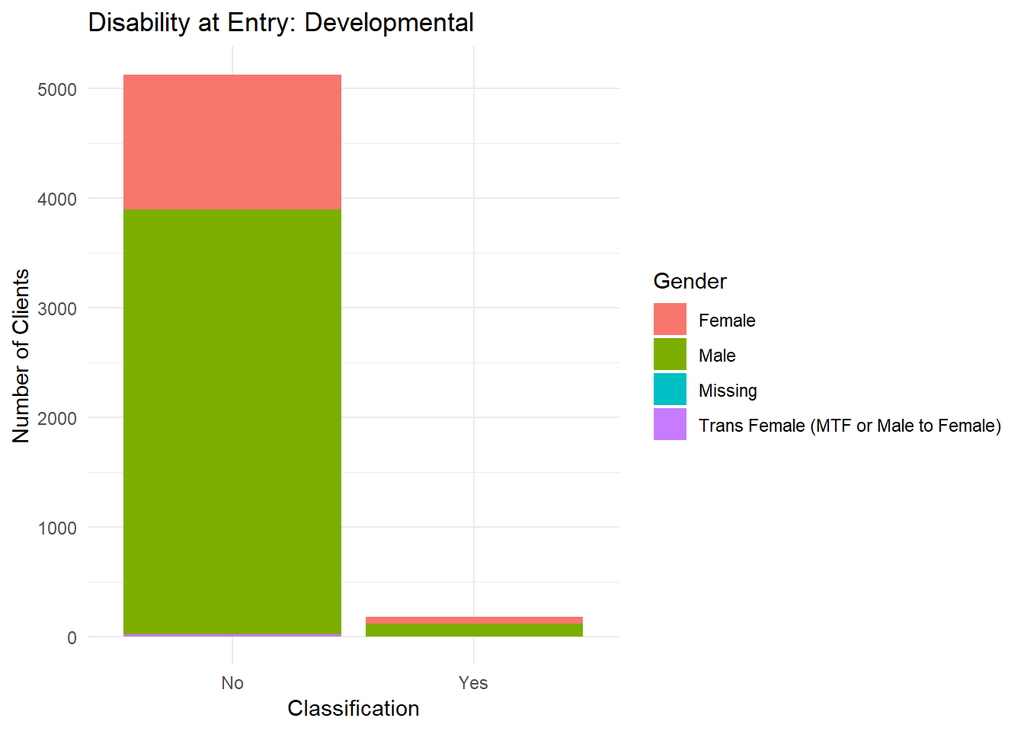

```r
ggplot(analysis.data, aes(x=`Developmental_Entry`)) + geom_bar(aes(fill=`Client Gender`),stat = "count") + labs(x="Classification", y="Number of Clients", fill = "Gender") + ggtitle("Disability at Entry: Developmental") + theme_minimal()
```

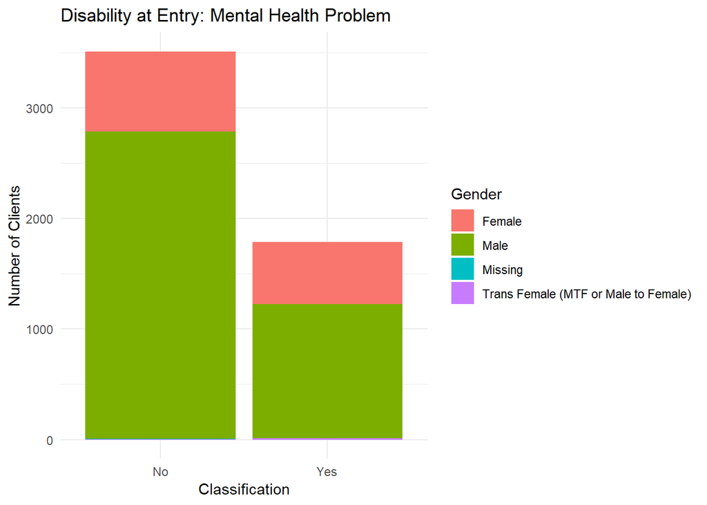

```r
ggplot(analysis.data, aes(x=`Mental Health Problem_Entry`)) + geom_bar(aes(fill=`Client Gender`),stat = "count") + labs(x="Classification", y="Number of Clients", fill = "Gender") + ggtitle("Disability at Entry: Mental Health Problem") + theme_minimal()
```

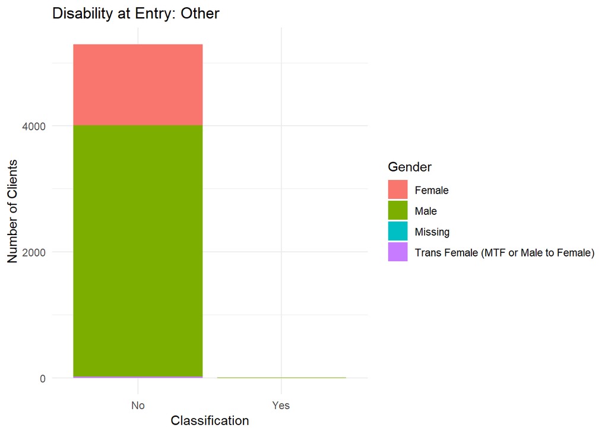

```r
ggplot(analysis.data, aes(x=`Other_Entry`)) + geom_bar(aes(fill=`Client Gender`),stat = "count") + labs(x="Classification", y="Number of Clients", fill = "Gender") + ggtitle("Disability at Entry: Other") + theme_minimal()
```

After conducting this preliminary investigation, I decided to perform a logistic regression to determine if any demographic factors were associated with whether or not a client had any disabilities when they first entered UMD.

```r
#run logistic regression predicting whether a client has a disabiity at entry based on their demographic factors
summary(glm(as.factor(`Disability_Entry`)~as.factor(`Client Gender`)+as.factor(`Client Primary Race`)+`Client Age at Entry`+as.factor(`Client Ethnicity`)+as.factor(`Client Veteran Status`), data = analysis.data, family = "binomial"))
```

```
##
## Call:
## glm(formula = as.factor(Disability_Entry) ~ as.factor(`Client Gender`) +
##     as.factor(`Client Primary Race`) + `Client Age at Entry` +
##     as.factor(`Client Ethnicity`) + as.factor(`Client Veteran Status`),
##     family = "binomial", data = analysis.data)
##
## Deviance Residuals:
##     Min       1Q   Median       3Q      Max
## -1.8294  -0.9486  -0.8884   1.3510   1.9505
##
## Coefficients:
##                                                                             Estimate
## (Intercept)                                                                -1.688579
## as.factor(`Client Gender`)Male                                             -0.585917
## as.factor(`Client Gender`)Trans Female (MTF or Male to Female)              1.248620
## as.factor(`Client Primary Race`)Asian                                       0.031853
## as.factor(`Client Primary Race`)Black or African American                  -0.019048
## as.factor(`Client Primary Race`)Client doesn't know                        13.335897
## as.factor(`Client Primary Race`)Client refused                              0.575937
## as.factor(`Client Primary Race`)Data not collected                         -0.834819
## as.factor(`Client Primary Race`)Native Hawaiian or Other Pacific Islander   0.495562
## as.factor(`Client Primary Race`)White                                       0.163089
## `Client Age at Entry`                                                       0.001634
## as.factor(`Client Ethnicity`)Client refused                                 1.725782
## as.factor(`Client Ethnicity`)Data not collected                             1.043122
## as.factor(`Client Ethnicity`)Hispanic/Latino                                0.818319
## as.factor(`Client Ethnicity`)Non-Hispanic/Non-Latino                        0.999778
## as.factor(`Client Veteran Status`)nan                                       0.317106
## as.factor(`Client Veteran Status`)No                                        0.502320
## as.factor(`Client Veteran Status`)Yes                                       0.664237
##                                                                           Std. Error
## (Intercept)                                                                 1.213742
## as.factor(`Client Gender`)Male                                              0.066548
## as.factor(`Client Gender`)Trans Female (MTF or Male to Female)              0.575618
## as.factor(`Client Primary Race`)Asian                                       1.245035
## as.factor(`Client Primary Race`)Black or African American                   0.223325
## as.factor(`Client Primary Race`)Client doesn't know                       162.011958
## as.factor(`Client Primary Race`)Client refused                              1.213315
## as.factor(`Client Primary Race`)Data not collected                          1.132791
```

[output cut: 63 more lines]

```
## as.factor(`Client Ethnicity`)Non-Hispanic/Non-Latino
## as.factor(`Client Veteran Status`)nan
## as.factor(`Client Veteran Status`)No
## as.factor(`Client Veteran Status`)Yes
## ---
## Signif. codes:  0 '***' 0.001 '**' 0.01 '*' 0.05 '.' 0.1 ' ' 1
##
## (Dispersion parameter for binomial family taken to be 1)
##
##     Null deviance: 7014.4  on 5295  degrees of freedom
## Residual deviance: 6899.1  on 5278  degrees of freedom
##   (3 observations deleted due to missingness)
## AIC: 6935.1
##
## Number of Fisher Scoring iterations: 11
```

The above regression found that client gender had a statistically significant association with the probability that a client had a disability when entering UMD. Specifically, males had $1-e^{-0.585917} = 44.3%$ lower odds of having a disability than females. The regression also found that being a trans-female was also statistically significant, but due to the low amount of trans-females in the sample compared to males and females, this find may not be accurate and was thus ignored. Thus, UMD may want to look into providing more in depth disability services for individuals that are more likely to have a disability, i.e. females.

Now, I wanted to determine which demographic characteristics, if any, could be related to whether or not a client who had at least one disability when they joined UMD no longer had any by the time they exited UMD.

```r
#run logistic regression predicting whether a client who had a disability at entry no longer had any at the time of their exit based on their demographic factors
summary(glm(as.factor(`Disability_Change`)~as.factor(`Client Gender`)+as.factor(`Client Primary Race`)+`Client Age at Entry`+as.factor(`Client Ethnicity`)+as.factor(`Client Veteran Status`), data = analysis.data, family = "binomial"), control = list(maxit=50))
```

```
##
## Call:
## glm(formula = as.factor(Disability_Change) ~ as.factor(`Client Gender`) +
##     as.factor(`Client Primary Race`) + `Client Age at Entry` +
##     as.factor(`Client Ethnicity`) + as.factor(`Client Veteran Status`),
##     family = "binomial", data = analysis.data)
##
## Deviance Residuals:
##        Min          1Q      Median          3Q         Max
## -2.409e-06  -2.409e-06  -2.409e-06  -2.409e-06  -2.409e-06
##
## Coefficients:
##                                                                             Estimate
## (Intercept)                                                               -2.657e+01
## as.factor(`Client Gender`)Male                                            -2.825e-13
## as.factor(`Client Gender`)Trans Female (MTF or Male to Female)            -2.510e-13
## as.factor(`Client Primary Race`)Asian                                      1.658e-13
## as.factor(`Client Primary Race`)Black or African American                 -5.203e-15
## as.factor(`Client Primary Race`)Client doesn't know                        5.041e-14
## as.factor(`Client Primary Race`)Client refused                             3.206e-13
## as.factor(`Client Primary Race`)Data not collected                         2.328e-13
## as.factor(`Client Primary Race`)Native Hawaiian or Other Pacific Islander  1.566e-13
## as.factor(`Client Primary Race`)White                                      2.815e-13
## `Client Age at Entry`                                                      8.044e-15
## as.factor(`Client Ethnicity`)Client refused                               -1.029e-13
## as.factor(`Client Ethnicity`)Data not collected                            2.778e-14
## as.factor(`Client Ethnicity`)Hispanic/Latino                              -7.648e-14
## as.factor(`Client Ethnicity`)Non-Hispanic/Non-Latino                       1.361e-13
## as.factor(`Client Veteran Status`)nan                                      2.037e-13
## as.factor(`Client Veteran Status`)No                                       1.989e-13
## as.factor(`Client Veteran Status`)Yes                                      1.117e-13
##                                                                           Std. Error
## (Intercept)                                                                1.867e+05
## as.factor(`Client Gender`)Male                                             1.165e+04
## as.factor(`Client Gender`)Trans Female (MTF or Male to Female)             8.704e+04
## as.factor(`Client Primary Race`)Asian                                      2.091e+05
## as.factor(`Client Primary Race`)Black or African American                  3.799e+04
## as.factor(`Client Primary Race`)Client doesn't know                        1.826e+05
## as.factor(`Client Primary Race`)Client refused                             2.093e+05
## as.factor(`Client Primary Race`)Data not collected                         1.526e+05
```

[output cut: 42 more lines]

```
## as.factor(`Client Ethnicity`)Data not collected                                  1
## as.factor(`Client Ethnicity`)Hispanic/Latino                                     1
## as.factor(`Client Ethnicity`)Non-Hispanic/Non-Latino                             1
## as.factor(`Client Veteran Status`)nan                                            1
## as.factor(`Client Veteran Status`)No                                             1
## as.factor(`Client Veteran Status`)Yes                                            1
##
## (Dispersion parameter for binomial family taken to be 1)
##
##     Null deviance: 0.0000e+00  on 5295  degrees of freedom
## Residual deviance: 3.0725e-08  on 5278  degrees of freedom
##   (3 observations deleted due to missingness)
## AIC: 36
##
## Number of Fisher Scoring iterations: 25
```

I then conducted my analysis of primary interest, i.e., what factors are associated with how long a client stays with UMD. I wanted to see if not only demographic factors but if or what disabilities were associated with a client’s length of stay. I first looked at a histogram of the lengths of clients’ stays to get an overall idea of how long clients tended to stay.

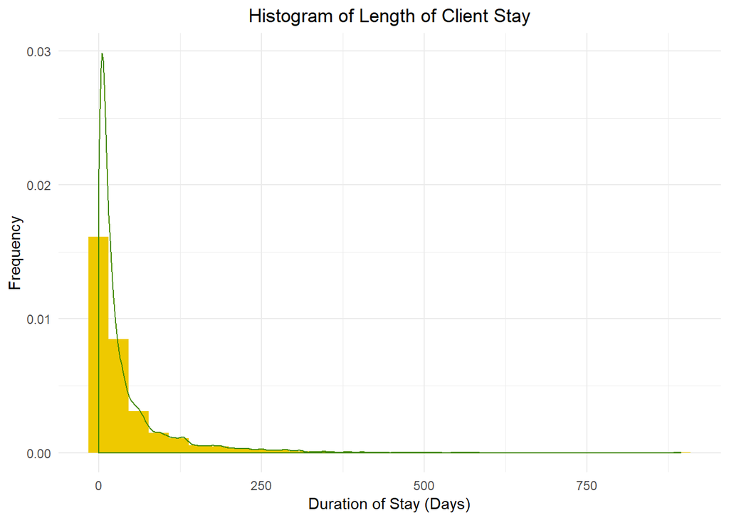

```r
#plot histogram of length of client stay
ggplot(data = analysis.data, aes(x=dur)) + geom_histogram(aes(y=..density..), fill="gold2") + geom_density(color="chartreuse4") + theme_minimal() + labs(x="Duration of Stay (Days)", y="Frequency") + ggtitle("Histogram of Length of Client Stay") + theme(plot.title = element_text(hjust=0.5))
```

From the histogram, it seems that the majority of clients tend to stay for between 0-100 days, and that increased stay length was associated with a decreased amount of clients.

```r
#run linear regression predicting length of client stay based on both demographic factors and disabilities at entry
summary(lm(dur~as.factor(`Client Gender`)+as.factor(`Client Primary Race`)+`Client Age at Entry`+as.factor(`Client Ethnicity`)+as.factor(`Client Veteran Status`) +as.factor(`Alcohol Abuse_Entry`)+as.factor(`Drug Abuse_Entry`)+as.factor(`Developmental_Entry`)+as.factor(`Mental Health Problem_Entry`)+as.factor(`Other_Entry`), data = analysis.data))
```

```
##
## Call:
## lm(formula = dur ~ as.factor(`Client Gender`) + as.factor(`Client Primary Race`) +
##     `Client Age at Entry` + as.factor(`Client Ethnicity`) + as.factor(`Client Veteran Status`) +
##     as.factor(`Alcohol Abuse_Entry`) + as.factor(`Drug Abuse_Entry`) +
##     as.factor(Developmental_Entry) + as.factor(`Mental Health Problem_Entry`) +
##     as.factor(Other_Entry), data = analysis.data)
##
## Residuals:
##    Min     1Q Median     3Q    Max
## -66.21 -33.34 -21.53   5.97 854.31
##
## Coefficients:
##                                                                            Estimate
## (Intercept)                                                               -20.18970
## as.factor(`Client Gender`)Male                                             -6.50247
## as.factor(`Client Gender`)Trans Female (MTF or Male to Female)             -4.59053
## as.factor(`Client Primary Race`)Asian                                      24.56863
## as.factor(`Client Primary Race`)Black or African American                  -1.91967
## as.factor(`Client Primary Race`)Client doesn't know                        35.39927
## as.factor(`Client Primary Race`)Client refused                              9.77188
## as.factor(`Client Primary Race`)Data not collected                         25.24459
## as.factor(`Client Primary Race`)Native Hawaiian or Other Pacific Islander  -5.81319
## as.factor(`Client Primary Race`)White                                      -4.29100
## `Client Age at Entry`                                                       0.57880
## as.factor(`Client Ethnicity`)Client refused                                 7.66614
## as.factor(`Client Ethnicity`)Data not collected                             9.15290
## as.factor(`Client Ethnicity`)Hispanic/Latino                               15.54956
## as.factor(`Client Ethnicity`)Non-Hispanic/Non-Latino                       27.60938
## as.factor(`Client Veteran Status`)nan                                      29.29078
## as.factor(`Client Veteran Status`)No                                       16.71899
## as.factor(`Client Veteran Status`)Yes                                      10.06417
## as.factor(`Alcohol Abuse_Entry`)Yes                                        -2.65775
## as.factor(`Drug Abuse_Entry`)Yes                                            5.93907
## as.factor(Developmental_Entry)Yes                                           0.64750
## as.factor(`Mental Health Problem_Entry`)Yes                                -4.96979
## as.factor(Other_Entry)Yes                                                  23.40239
##                                                                           Std. Error
## (Intercept)                                                                 34.32789
## as.factor(`Client Gender`)Male                                               2.08953
```

[output cut: 85 more lines]

```
## as.factor(`Client Veteran Status`)nan
## as.factor(`Client Veteran Status`)No
## as.factor(`Client Veteran Status`)Yes
## as.factor(`Alcohol Abuse_Entry`)Yes
## as.factor(`Drug Abuse_Entry`)Yes
## as.factor(Developmental_Entry)Yes
## as.factor(`Mental Health Problem_Entry`)Yes                               **
## as.factor(Other_Entry)Yes
## ---
## Signif. codes:  0 '***' 0.001 '**' 0.01 '*' 0.05 '.' 0.1 ' ' 1
##
## Residual standard error: 62.4 on 5166 degrees of freedom
##   (110 observations deleted due to missingness)
## Multiple R-squared:  0.01895,    Adjusted R-squared:  0.01478
## F-statistic: 4.537 on 22 and 5166 DF,  p-value: 9.443e-12
```

From the above model, I found that gender, age, and Mental Health Problems were all statistically significantly associated with length of stay. Specifically, the model indicates that males stay on average for 6.5 less days than females, clients with Mental Health Problems stayed on average for 5 less days than clients who did not have mental health problems, and a 1 year increase in client age was associated with an average increase in stay length of 0.58 days. It is not immediately clear as to why these factors may be associated with length of stay. It may be that women stay longer on average than males as they have children with them, but this is merely a conjecture. UMD may want to look into why these factors are associated with stay duration so they can understand what they can be changed such that it takes less time for clientele to be self-sufficient.

As the p-value for client age was the smallest, i.e., age was the most “significant” factor, I decided to look further into how age is distributed in the population and its relationship with stay duration.

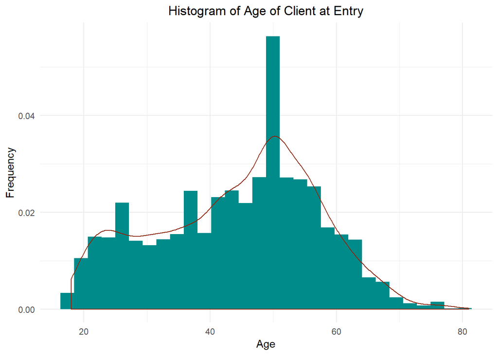

```r
#plot histogram of age of clients at entry to UMD
ggplot(data = analysis.data, aes(x=`Client Age at Entry`)) + geom_histogram(aes(y=..density..), fill="darkcyan") + geom_density(color="orangered4") + theme_minimal() + labs(x="Age", y="Frequency") + ggtitle("Histogram of Age of Client at Entry") + theme(plot.title = element_text(hjust=0.5))
```

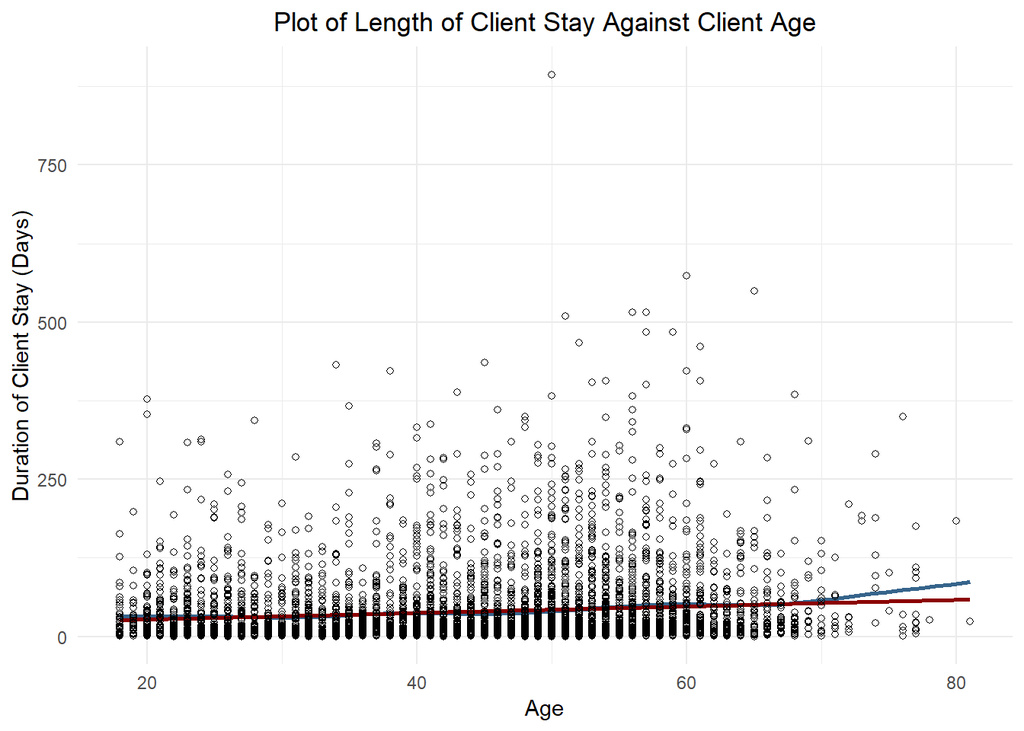

```r
#plot dot plot of age of clients at entry to UMD overlayed with linear regression line and smoothed kernel line
ggplot(analysis.data, aes(x=`Client Age at Entry`, y=dur)) + geom_smooth(se=FALSE, color = "steelblue4") + geom_smooth(method = "lm", se=FALSE, color='darkred') + geom_point(shape = 1) + theme_minimal() + labs(x="Age", y="Duration of Client Stay (Days)") + ggtitle("Plot of Length of Client Stay Against Client Age") + theme(plot.title = element_text(hjust=0.5))
```

From the above histogram, it seems that client age is somewhat evenly distributed, though it seems that there are more people of about age 50 than there are of other ages, and that there are few clients at UMD above age 60. The second graph plots the ages of all individuals against their respective stay lengths, and provides a regression line and smoothed kernel line of the relationship between age and stay duration. Though the the slope of the regression line is indeed significant, the data points themselves do not seem to follow any sort of pattern linear or otherwise, indicating that there might not actually be a relationship between age and stay duration. Looking at the plot, There seems to be an outlier where a client stayed for over 800 days, which may have contributed to why the linear regression was statistically significant.